# WGCNA Co-expression Network Analysis: Ewing Sarcoma (GSE17679)

Tumor-vs-Normal and Survival-Associated Module Discovery

Musfirah Tanveer

2026-07-19

```
## Allowing multi-threading with up to 4 threads.
```

## Abstract

This analysis applies Weighted Gene Co-expression Network Analysis (WGCNA) to **GSE17679**, an independent Ewing Sarcoma cohort (88 tumor samples, 18 normal skeletal muscle samples, Affymetrix HG-U133 Plus 2.0), to test whether **NKX2-2** — previously identified as a diagnostic (DESeq2, GSE2553) and prognostic (Cox regression, GSE63157) biomarker — also holds up as a network-level hub gene in a third, independent dataset. Two complementary network analyses were performed: (1) tumor vs. normal tissue, and (2) a within-tumor comparison by vital status (Dead vs. No Evidence of Disease). NKX2-2 showed strong module membership in both networks (MM = 0.92 and MM = 0.53, respectively), and a within-tumor module enriched for cell-cycle/proliferation genes was found to correlate significantly with survival outcome (r = 0.36, p = 7×10⁻⁴).

## 1. Introduction

Ewing Sarcoma is a pediatric bone and soft-tissue malignancy driven by the EWSR1-FLI1 fusion oncogene. Prior work in this project series established NKX2-2, a homeodomain transcription factor, as (1) the top differentially upregulated gene distinguishing Ewing Sarcoma from other sarcoma subtypes (DESeq2 on GSE2553), (2) a significant prognostic marker of overall and event-free survival (Cox regression on GSE63157), and (3) the top hub gene of an Ewing-specific, GO-enriched co-expression module (WGCNA on GSE2553, restricted to 5 major sarcoma subtypes).

## 2. Methods

### 2.1 Data Source & Sample Selection

GSE17679 (Affymetrix HG-U133 Plus 2.0, GPL570) was downloaded via GEOquery. Of 117 total samples, 11 in vitro cultured cell line samples were excluded (systematically different expression from primary tissue due to absence of tumor microenvironment). The remaining 106 samples (88 primary Ewing Sarcoma tumor, 18 normal skeletal muscle) were retained for network construction.

### 2.2 Quality Control

Expression data were confirmed already log2/RMA-normalized (comparable medians across samples on visual inspection). Data were transposed to WGCNA’s required samples-as-rows orientation and passed through `goodSamplesGenes()` prior to any network construction. Sample outliers were assessed via average-linkage hierarchical clustering on Euclidean distance.

### 2.3 Network Construction

For each of the two comparisons (tumor-vs-normal; within-tumor survival status), analysis proceeded independently: gene filtering to the top 5,000 most-variable probes, soft-thresholding power selection via `pickSoftThreshold()` targeting scale-free topology fit R² > 0.85 (signed network), module detection via `blockwiseModules()` (`networkType = "signed"`, `TOMType = "signed"`, `minModuleSize = 30`, `mergeCutHeight = 0.25`), and module eigengene correlation against the relevant trait. `set.seed(1234)` was fixed prior to each network build for reproducibility. Hub genes were identified by module membership (correlation of each gene to its module eigengene) and mapped to gene symbols via the `hgu133plus2.db` annotation package. Modules were selected for downstream reporting dynamically (by strength of trait correlation), not by hardcoded module number, to avoid reproducibility issues from run-to-run module relabeling.

### 2.4 Enrichment

GO Biological Process enrichment (2023 release) was performed on the top 200 module-member genes via `enrichR`.

## 3. Results — Analysis 1: Tumor vs. Normal Tissue

### 3.1 Sample Quality Control

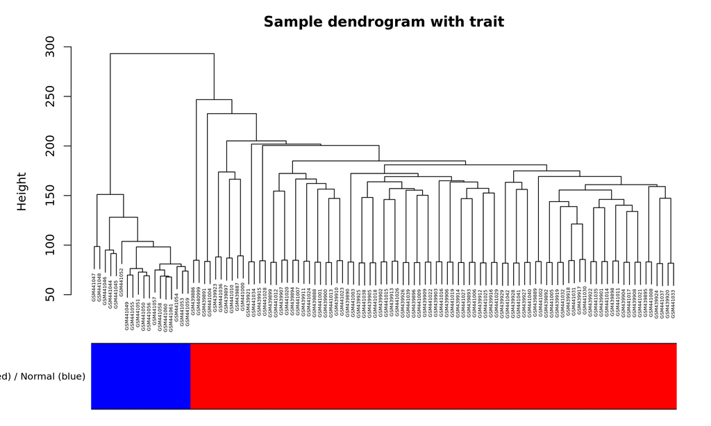

Figure 1: Sample clustering colored by tissue type (red = tumor, blue = normal)

Sample clustering (Figure 1) shows a clean, expected split: normal muscle samples separate from tumor samples at a high fusion height, consistent with real biological signal rather than a technical artifact. No samples were removed.

### 3.2 Soft-Thresholding Power Selection

```
##    Power SFT.R.sq  slope truncated.R.sq mean.k. median.k. max.k.
## 1      1   0.4910  3.630          0.709  2680.0    2790.0   3080
## 2      2   0.1920  1.550          0.315  1670.0    1660.0   2270
## 3      3   0.0853  0.628          0.436  1130.0    1040.0   1810
## 4      4   0.0192 -0.158          0.473   812.0     750.0   1490
## 5      5   0.3050 -0.517          0.651   609.0     573.0   1260
## 6      6   0.5440 -0.671          0.843   472.0     441.0   1090
## 7      7   0.6240 -0.755          0.829   376.0     340.0    952
## 8      8   0.6540 -0.818          0.801   306.0     263.0    843
## 9      9   0.6620 -0.870          0.772   253.0     205.0    752
## 10    10   0.6660 -0.902          0.761   213.0     161.0    676
## 11    12   0.6740 -0.963          0.729   156.0     102.0    557
## 12    14   0.6950 -0.970          0.721   119.0      67.1    466
## 13    16   0.7720 -0.943          0.772    92.9      45.1    396
## 14    18   0.9170 -0.915          0.918    74.3      31.1    345
## 15    20   0.8990 -0.995          0.921    60.6      21.7    320
```

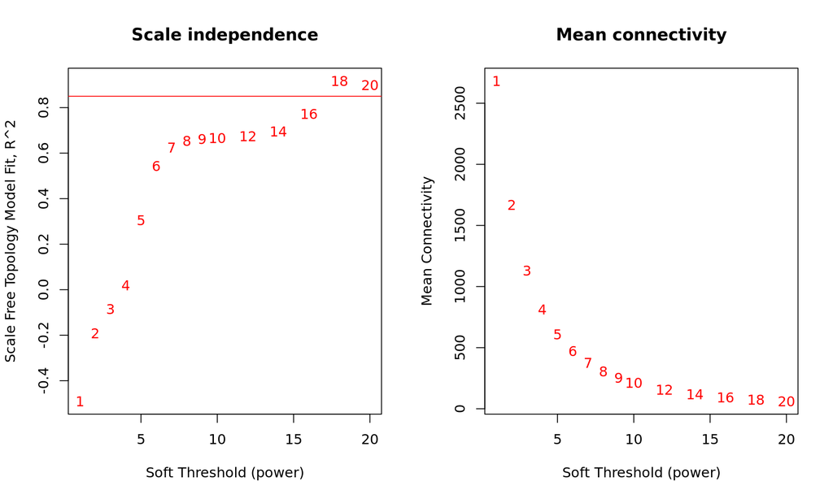

Figure 2: Scale-free topology fit and mean connectivity across candidate powers (tumor vs. normal network)

Power **18** was selected as the lowest power at which R² clearly exceeded 0.85 (R² = 0.917) with acceptable mean connectivity (74.3). Signed networks typically require higher powers (12-30) than unsigned networks (6-10) to reach equivalent fit, which this result is consistent with.

### 3.3 Network Construction & Modules

Table 1: Module sizes, tumor-vs-normal network

| Module | N_genes |
| --- | --- |
| 0 (unassigned/grey) | 526 |
| 1 | 2261 |
| 2 | 1082 |
| 3 | 739 |
| 4 | 254 |
| 5 | 80 |
| 6 | 58 |

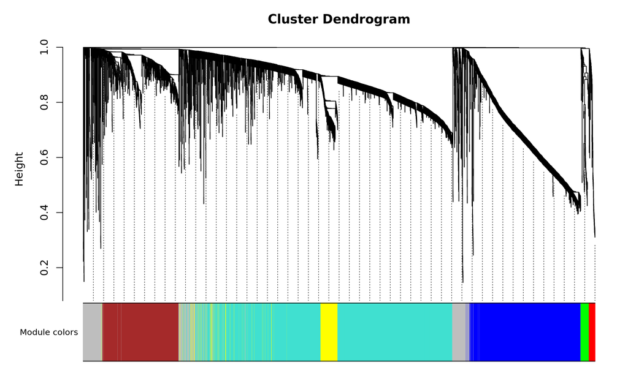

Figure 3: Gene dendrogram and module assignment (tumor vs. normal network)

The unassigned (grey) module comprised 10.5% of genes, within the expected healthy range (10-20%), indicating the network found real co-expression structure.

### 3.4 Module-Trait Correlation

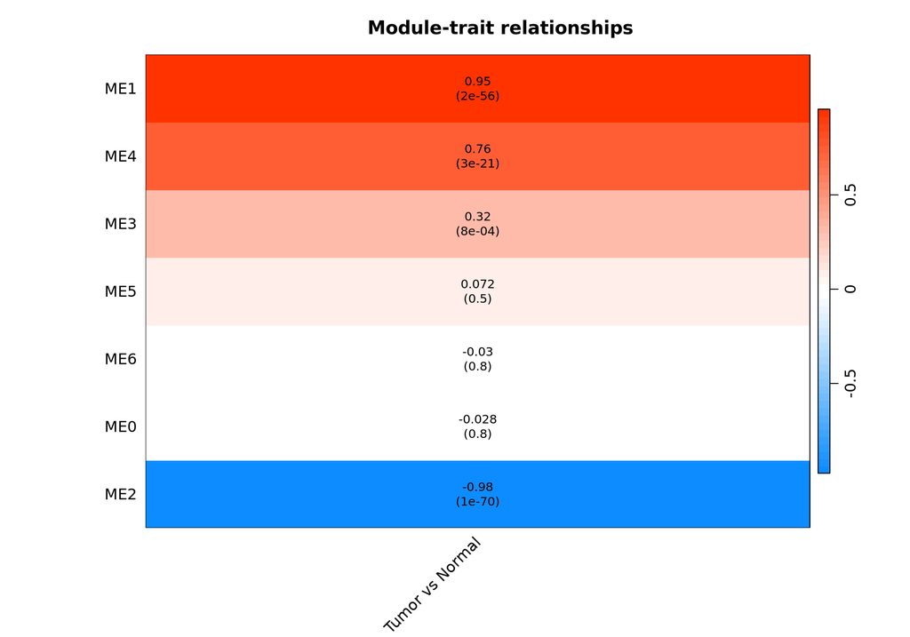

Figure 4: Module-trait relationships, tumor vs. normal tissue

Two modules showed very strong correlation with tumor status: **ME1** (r = 0.95, p = 1.9×10⁻⁵⁶, tumor-associated) and **ME2** (r = −0.98, p = 1.3×10⁻⁷⁰, normal-tissue-associated). Both survive Bonferroni correction for 7 modules tested (α ≈ 0.007).

### 3.5 Hub Genes & NKX2-2 Standing

Table 2: Top hub genes, ME1 (tumor-associated)

|  | symbol | MM_ME1 |
| --- | --- | --- |
| 222431_at | SPIN1 | 0.9748749 |
| 212039_x_at | RPL3 | 0.9707298 |
| 201217_x_at | RPL3 | 0.9681060 |
| 211073_x_at | RPL3 | 0.9674062 |
| 1553959_a_at | B3GALT6 | 0.9663427 |
| 217813_s_at | SPIN1 | 0.9660780 |
| 200746_s_at | GNB1 | 0.9624358 |
| 204892_x_at | EEF1A1 | 0.9621856 |
| 227663_at | NA | 0.9610546 |
| 230653_at | LOC105369228 | 0.9590689 |
| 206559_x_at | EEF1A1 | 0.9586613 |
| 210719_s_at | HMG20B | 0.9571769 |
| 218387_s_at | PGLS | 0.9556821 |
| 215963_x_at | RPL3 | 0.9551130 |
| 201745_at | TWF1 | 0.9545021 |

Table 3: Top hub genes, ME2 (normal-tissue-associated)

|  | symbol | MM_ME2 |
| --- | --- | --- |
| 216887_s_at | LDB3 | 0.9868534 |
| 228406_at | SMYD1 | 0.9864854 |
| 230429_at | ASPH | 0.9855699 |
| 235617_x_at | STRIT1 | 0.9853020 |
| 219926_at | POPDC3 | 0.9842964 |
| 222954_at | FBXO40 | 0.9838338 |
| 227834_at | TXLNB | 0.9835767 |
| 1564469_at | LMOD3 | 0.9834622 |
| 222287_at | TRDN | 0.9833823 |
| 219645_at | CASQ1 | 0.9831772 |
| 232298_at | MBNL1-AS1 | 0.9830963 |
| 205577_at | PYGM | 0.9804439 |
| 206353_at | COX6A2 | 0.9803571 |
| 216265_x_at | MYH7 | 0.9802248 |
| 228783_at | POPDC1 | 0.9801822 |

**NKX2-2** (probe 206915_at) had module membership MM = 0.918 in ME1, ranking 166 of 2261 genes (top 7.3%) — a strong, hub-range correlation, though not the module’s top-ranked gene.

Table 4: GO Biological Process enrichment, ME1

| Term | P.value | Adjusted.P.value |
| --- | --- | --- |
| Chromatin Organization (GO:0006325) | 0.0001953 | 0.0722975 |
| mRNA Processing (GO:0006397) | 0.0002161 | 0.0722975 |
| Positive Regulation Of Viral Process (GO:0048524) | 0.0002481 | 0.0722975 |
| Regulation Of DNA-templated Transcription Elongation (GO:0032784) | 0.0003268 | 0.0722975 |
| Late Endosome To Vacuole Transport (GO:0045324) | 0.0004292 | 0.0734597 |
| Focal Adhesion Assembly (GO:0048041) | 0.0004980 | 0.0734597 |
| Endosome Transport Via Multivesicular Body Sorting Pathway (GO:0032509) | 0.0007455 | 0.0827795 |
| RNA Polyadenylation (GO:0043631) | 0.0008425 | 0.0827795 |
| Regulation Of RNA Splicing (GO:0043484) | 0.0010309 | 0.0827795 |
| mRNA Splicing, Via Spliceosome (GO:0000398) | 0.0010852 | 0.0827795 |

## 4. Results — Analysis 2: Within-Tumor Survival Status

Because the tumor-vs-normal network above is dominated by the large tissue-type signal, a second network was built using only the 88 tumor samples, to allow finer within-tumor co-expression structure — related to clinical outcome — to emerge.

### 4.1 Cohort & Trait

Vital status (`status:ch1`) was used as a binary trait: Dead (n=52) vs. No Evidence of Disease (NED, n=34). Samples with intermediate “Alive With Disease” status (n=2) were excluded as too few for reliable grouping.

### 4.2 Soft-Thresholding Power & Network Construction

```
##    Power SFT.R.sq   slope truncated.R.sq mean.k. median.k. max.k.
## 1      1 2.74e-02  2.4800          0.889 2660.00   2650.00   3050
## 2      2 3.10e-06  0.0129          0.853 1480.00   1460.00   1980
## 3      3 2.32e-02 -0.6900          0.820  868.00    831.00   1360
## 4      4 1.01e-01 -0.9950          0.767  531.00    492.00    985
## 5      5 2.52e-01 -1.2100          0.725  339.00    300.00    740
## 6      6 5.22e-01 -1.4300          0.751  225.00    190.00    574
## 7      7 7.33e-01 -1.5900          0.840  154.00    124.00    462
## 8      8 8.21e-01 -1.6600          0.880  109.00     83.40    383
## 9      9 8.55e-01 -1.7000          0.902   79.50     56.90    323
## 10    10 8.67e-01 -1.7000          0.912   59.40     39.70    276
## 11    12 8.62e-01 -1.7200          0.918   35.40     20.30    208
## 12    14 8.54e-01 -1.7300          0.928   22.60     10.90    161
## 13    16 8.60e-01 -1.7000          0.944   15.30      6.26    127
## 14    18 8.56e-01 -1.7000          0.955   10.90      3.81    102
## 15    20 8.50e-01 -1.7000          0.956    7.99      2.44     83
```

Power **9** was selected (R² = 0.855, mean connectivity = 79.5). The somewhat lower plateau R² compared to the tumor-vs-normal network (0.85-0.87 vs. 0.92) is expected for a more homogeneous, single-tissue- type cohort, where no single dominant signal drives network structure.

Table 5: Module sizes, within-tumor survival network

| Module | N_genes |
| --- | --- |
| 0 (unassigned/grey) | 706 |
| 1 | 1729 |
| 2 | 746 |
| 3 | 461 |
| 4 | 221 |
| 5 | 212 |
| 6 | 208 |
| 7 | 199 |
| 8 | 187 |
| 9 | 132 |
| 10 | 101 |
| 11 | 61 |
| 12 | 37 |

Grey module comprised 14.1% of genes — again within the healthy range.

### 4.3 Module-Trait Correlation (Survival Status)

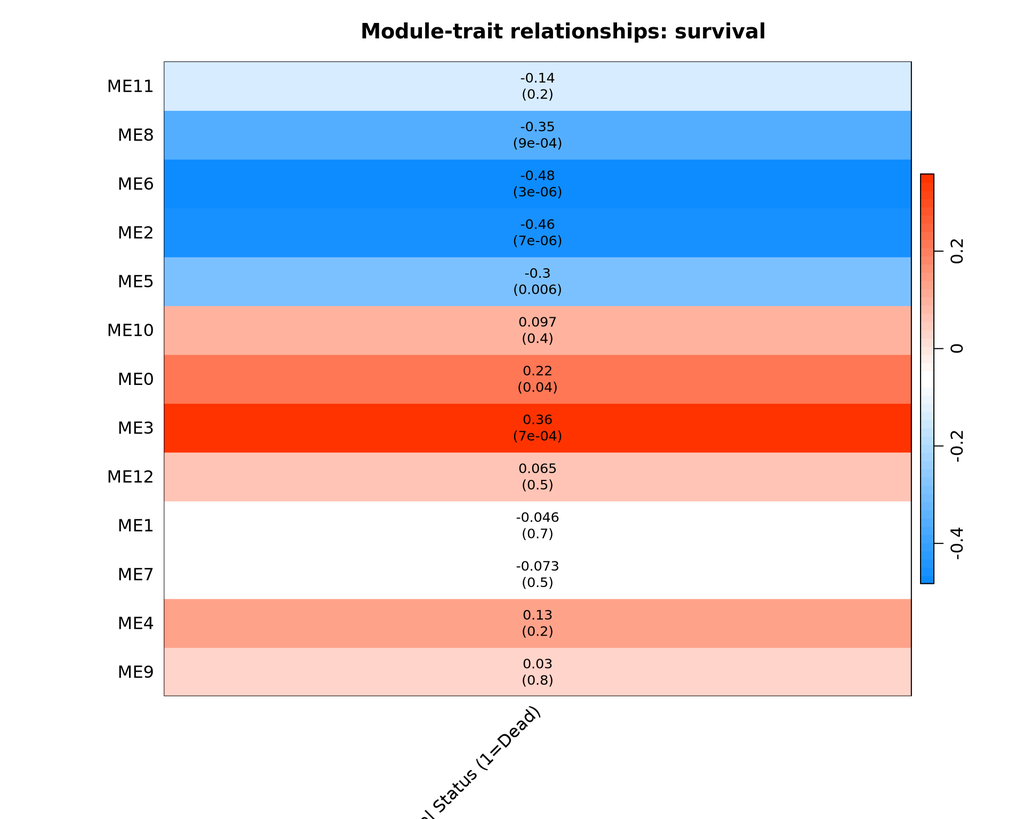

Figure 5: Module-trait relationships, vital status (Dead vs. NED)

Four modules survived Bonferroni correction (α ≈ 0.0038 for 13 modules): **ME6** (r = −0.48, p = 2.6×10⁻⁶), **ME2** (r = −0.46, p = 7.3×10⁻⁶), **ME3** (r = 0.36, p = 7.1×10⁻⁴), and **ME8** (r = −0.35, p = 9.3×10⁻⁴). Negative correlations indicate modules elevated in NED (surviving) patients; the positive ME3 correlation indicates a module elevated in patients who died.

### 4.4 Hub Genes: Proliferation Module (ME3) and NKX2-2’s Module (ME2)

Table 6: Top hub genes, ME3 (proliferation, risk-associated)

|  | Symbol |
| --- | --- |
| 203145_at | SPAG5 |
| 207828_s_at | CENPF |
| 211519_s_at | KIF2C |
| 203755_at | BUB1B |
| 209642_at | BUB1 |
| 203046_s_at | TIMELESS |
| 209408_at | KIF2C |
| 212949_at | NCAPH |
| 236641_at | KIF14 |
| 202107_s_at | MCM2 |
| 204962_s_at | CENPA |
| 218585_s_at | DTL |
| 204825_at | MELK |
| 218875_s_at | FBXO5 |
| 223381_at | NUF2 |

Table 7: Top hub genes, ME2 (protective, contains NKX2-2)

|  | Symbol |
| --- | --- |
| 201648_at | JAK1 |
| 227256_at | USP31 |
| 235068_at | ZDHHC21 |
| 229240_at | ZDHHC21 |
| 227817_at | PRKCB |
| 213552_at | GLCE |
| 207957_s_at | PRKCB |
| 209685_s_at | PRKCB |
| 39966_at | CSPG5 |
| 1552611_a_at | JAK1 |
| 228795_at | PRKCB |
| 227824_at | PRKCB |
| 226106_at | RNF141 |
| 243835_at | ZDHHC21 |
| 229309_at | ADRB1 |

**ME3** is a clean, textbook mitotic/cell-cycle module (`SPAG5`, `CENPF`, `KIF2C`, `BUB1B`, `BUB1`, `MCM2`, `CENPA`) — higher activity of this proliferation program predicts worse survival, a biologically expected finding in cancer prognosis broadly.

Table 8: GO Biological Process enrichment, ME2

| Term | P.value | Adjusted.P.value |
| --- | --- | --- |
| Adrenergic Receptor Signaling Pathway (GO:0071875) | 0.0000001 | 0.0000922 |
| Positive Regulation Of Heart Rate (GO:0010460) | 0.0000038 | 0.0020378 |
| Adenylate Cyclase-Activating Adrenergic Receptor Signaling Pathway (GO:0071880) | 0.0001153 | 0.0412426 |
| Regulation Of Glucose Transmembrane Transport (GO:0010827) | 0.0001707 | 0.0457903 |
| Protein Localization To Membrane (GO:0072657) | 0.0002632 | 0.0564905 |
| Protein Localization To Cell Periphery (GO:1990778) | 0.0003339 | 0.0597146 |
| Negative Regulation Of Establishment Of Protein Localization To Mitochondrion (GO:1903748) | 0.0006182 | 0.0838775 |
| Regulation Of Vasoconstriction (GO:0019229) | 0.0006254 | 0.0838775 |
| Adenylate Cyclase-Activating G Protein-Coupled Receptor Signaling Pathway (GO:0007189) | 0.0007620 | 0.0908456 |
| Positive Regulation Of Microtubule Polymerization (GO:0031116) | 0.0008665 | 0.0929722 |

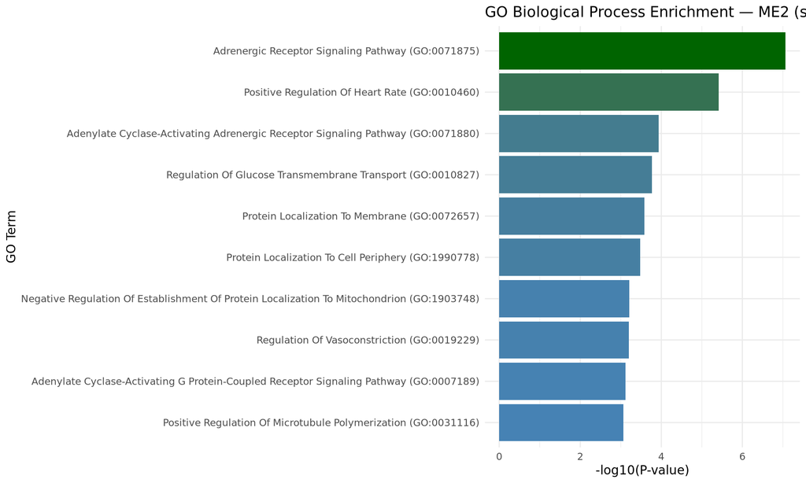

Figure 6: Top enriched GO Biological Process terms, ME2

## 5. Discussion

This analysis provides a **fourth independent line of evidence** for NKX2-2’s relevance in Ewing Sarcoma biology, following diagnostic (DESeq2, GSE2553), prognostic (Cox regression, GSE63157), and network-topology (WGCNA, GSE2553) evidence from prior work in this project series:

- In an independent cohort (GSE17679) and independent array platform, NKX2-2 showed strong module membership (MM = 0.92, top 7%) in the dominant tumor-vs-normal module, though that module’s biology reflected general proliferation/translation machinery rather than a disease-specific signature (GO enrichment non-significant).
- In a refined, within-tumor analysis using vital status, NKX2-2 showed significant, moderate hub-gene-range membership (MM = 0.53) in a GO-enriched, survival-protective module (ME2, r = −0.46, p = 7.3×10⁻⁶ with death).
- An independent, strongly significant proliferation module (ME3) was also identified as predictive of survival (r = 0.36, p = 7.1×10⁻⁴), representing a standalone finding of value regardless of NKX2-2’s involvement.

These results should be read as **corroborating, moderate-strength evidence** rather than a replication of the sharper, top-hub-gene result obtained on GSE2553 (where NKX2-2 was module ME14’s single strongest member, r = 0.94 with subtype). The difference is expected: GSE2553’s WGCNA compared Ewing against other sarcoma *subtypes*, a comparison that directly isolates Ewing-specific identity genes, whereas GSE17679’s primary comparison (tumor vs. normal muscle) is dominated by broader “malignant vs. non-malignant” signal. The survival-status refinement within GSE17679 recovers a sharper, biologically interpretable signal more comparable to the GSE2553 result.

## References

1. GSE17679: NCBI GEO
2. WGCNA: Langfelder P, Horvath S. BMC Bioinformatics (2008)
3. enrichR: Kuleshov MV et al. Nucleic Acids Research (2016)
4. R Core Team (2024)